# Algothon 2021 - ML Strategy Challenge

For : http://www.algothon.org/challenges.html

Joint work between [Sanjit Neelam](https://github.com/sanj909), and [Chris Chia](https://github.com/chrischia06/)

**Preliminaries** : requires Python 3.8, the `numpy`, `pandas`, `lightgbm` `matplotlib` , `seaborn`, `statsmodels`, `scikit-learn`, `shap` packages. The `yfinance`, `quandl` packages are optional. Requires the data provided by the challenge organisers from https://drive.google.com/drive/folders/180FaVThDIFtmrCZ2cGiYskvlyvyMv5Au, which is included in the `data` directory.

- Preprocessing
- Exploratory Data Analysis
- Modelling - LightGBM
- Evaluation: Model Predictions
- Evaluation: Interpretability

```python
import numpy as np
import pandas as pd
import lightgbm as lgb
from numpy import random
import shap

import matplotlib.pyplot as plt
import seaborn as sns
from statsmodels.graphics.tsaplots import plot_acf, plot_pacf
from sklearn.metrics import confusion_matrix

from ml_strat import *

import warnings
warnings.filterwarnings('ignore')

plt.style.use("fivethirtyeight")
```

# Task

- In short, the task is to come up with a **meta-model** that can predict the performance of the trade, and what position between $[-1, 1]$ to take in it. The evaluation metric is the *Sharpe Ratio* from the prediction and the actual return $\hat{y}_{i} \cdot r_{i}$.

# Preprocessing

We read in all the provided data, define all transformations and apply them.

- For now, we only encode the Trading Date by Month, Date, Year
- The time stamp is time on and time off is fixed 8pm every day.

# External Data

We select some external variables that might be general enough to help us predict performance

- U.S. Treasury Bond Futures, Continuous Contract #1 (US1) (Front Month). Link: https://www.quandl.com/data/CHRIS/CME_US1 #
- Crude Oil Futures, Continuous Contract (CL1) (Front Month). Link: https://www.quandl.com/data/CHRIS/CME_CL1 # #1 (
- Bond: U.S. Treasury Bond Futures, Continuous Contract #1 (US1) (Front Month) from Quandl. Link: https://www.quandl.com/data/CHRIS/CME_GC1
- USD index futures. Link: https://www.quandl.com/data/CHRIS/ICE_DX1
- S&P 500 Futures, Continuous Contract #1 (SP1)
- Gold Futures, Continuous Contract #1 (GC1) (Front Month)
- Commodity: S&P GSCI Index (^SPGSCI) from yfinance
- Currency: USD Index from investing.com
- Stock: https://www.quandl.com/data/CHRIS/CME_SP1
- US 10 Year T Note: https://uk.investing.com/rates-bonds/us-10-yr-t-note-historical-data

We use primarily the current **Open**, and previous **Close** and **Volume** prices.

```python
assets = ['bond_1', 'bond_2', 'commodity_1', 'commodity_2', 'currency_1',
          'currency_2', 'stock_1', 'stock_2']
symbols = [("-TBond Futures", "CHRIS/CME_US1"), ("Crude Futures", "CHRIS/CME_CL1"),
           ("Gold Futures", "CHRIS/CME_CL2"), ("USD Futures", "CHRIS/ICE_DX1"),
           ("SP500 Futures","CHRIS/CME_SP1")]
tickers = ["^VIX", "^GSPC","^FTSE","USDGBP=X","EURGBP=X"]


#### Collect Data from APIs. If running locally, skip this step. ####
df = pd.DataFrame()
#### join all the data ####
path = "data"
for a in assets:
    try:
        temp = pd.read_csv(f"{path}/{a}.csv")
    except:
        try:
            temp = pd.read_csv(f"{a}.csv")
        except:
            pass
    if temp.shape[0] != 0: #if temp is non-empty
        try:
            df = pd.concat([df, temp], axis=0).reset_index(drop=True)
        except:
            print("Some error")

df3 = preprocess(df)

#### Comment these lines if running locally. ####
# quandl_dfs = get_quandl_data(symbols, "pkLbjb4QQUmszgP48_jC", path)
dfs = get_y_finance_feats(tickers, path)

#### Read in saved data, rather than using API ####
quandl_dfs = {}
yf_dfs = {}
for x in symbols:
    quandl_dfs[x[0]] = pd.read_csv(f"{path}/{x[0]}.csv")
for x in tickers:
    yf_dfs[x] = pd.read_csv(f"{path}/{x}.csv")

us10yr = pd.read_csv(f"{path}/US 10 YR T-Note Futures Historical Data.csv")
us10yr['Date'] = pd.to_datetime(us10yr["Date"])
us10yr = us10yr[['Date','Open']]
us10yr.columns = ["Date","US10Yr-Open"]

df2  = df3.copy()
for x in yf_dfs:
    yf_dfs[x]['Date'] = pd.to_datetime(yf_dfs[x]['Date'])
    df2 = pd.merge(df2, yf_dfs[x], on ='Date', how='left')

for x in quandl_dfs:
    quandl_dfs[x]['Date'] = pd.to_datetime(quandl_dfs[x]['Date'])
    df2 = pd.merge(df2, quandl_dfs[x], on ='Date', how='left')

df2 = pd.merge(df2, us10yr, how='left',on='Date')

cat_feats =['Market']
df2[cat_feats]  = df2[cat_feats].astype("category")
display(df2)
```

|  | Date | Market | Return | Entry | Year | Month | Day | ^VIX-Open | ^VIX-Close | ^VIX-Rets | ... | Gold Futures-Volume | Gold Futures-Previous Day Open Interest | Gold Futures-Open | USD Futures-Volume | USD Futures-Prev. Day Open Interest | USD Futures-Open | SP500 Futures-Volume | SP500 Futures-Previous Day Open Interest | SP500 Futures-Open | US10Yr-Open |
| --- | --- | --- | --- | --- | --- | --- | --- | --- | --- | --- | --- | --- | --- | --- | --- | --- | --- | --- | --- | --- | --- |
| 0 | 2012-11-07 | bond_1 | -0.257833 | 0 | 2012 | 11 | 7 | 17.719999 | 17.580000 | 0.007932 | ... | 72502.0 | 225676.0 | 88.76 | 24315.0 | 35614.0 | 80.785 | 5703.0 | 204290.0 | 1424.9 | 132.66 |
| 1 | 2012-11-20 | bond_1 | 0.022210 | 1 | 2012 | 11 | 20 | 15.110000 | 15.240000 | -0.008567 | ... | 49831.0 | 134660.0 | 89.60 | 17425.0 | 36993.0 | 81.025 | 11007.0 | 220451.0 | 1379.9 | 133.95 |
| 2 | 2012-11-28 | bond_1 | -0.436010 | 0 | 2012 | 11 | 28 | 16.430000 | 15.920000 | 0.031533 | ... | 37492.0 | 158521.0 | 87.94 | 18571.0 | 32940.0 | 80.390 | 8179.0 | 216620.0 | 1397.4 | 133.77 |
| 3 | 2012-12-03 | bond_1 | -0.209771 | 0 | 2012 | 12 | 3 | 15.810000 | 15.870000 | -0.003788 | ... | 56936.0 | 174864.0 | 89.45 | 15892.0 | 32939.0 | 80.195 | 8357.0 | 211908.0 | 1413.2 | 134.05 |
| 4 | 2012-12-05 | bond_1 | -0.313398 | 0 | 2012 | 12 | 5 | 16.950001 | 17.120001 | -0.009980 | ... | 38194.0 | 185398.0 | 89.03 | 21297.0 | 38796.0 | 79.620 | 7556.0 | 208499.0 | 1401.8 | 134.09 |
| ... | ... | ... | ... | ... | ... | ... | ... | ... | ... | ... | ... | ... | ... | ... | ... | ... | ... | ... | ... | ... | ... |
| 8767 | 2021-03-01 | stock_2 | 1.345958 | 0 | 2021 | 3 | 1 | 25.200001 | 27.950001 | -0.103573 | ... | 120240.0 | 284806.0 | 61.42 | 49289.0 | 35802.0 | 90.900 | 5078.0 | 30661.0 | 3846.7 | 134.27 |
| 8768 | 2021-03-04 | stock_2 | -0.123132 | 7 | 2021 | 3 | 4 | 26.520000 | 26.670000 | -0.005640 | ... | 163978.0 | 289658.0 | 60.93 | 28972.0 | 33745.0 | 91.025 | 1550.0 | 32429.0 | 3803.4 | 134.06 |
| 8769 | 2021-03-05 | stock_2 | 0.388406 | 9 | 2021 | 3 | 5 | 29.480000 | 28.570000 | 0.031355 | ... | 229281.0 | 299696.0 | 63.94 | 36468.0 | 35911.0 | 91.640 | 4114.0 | 31598.0 | NaN | 133.44 |
| 8770 | 2021-03-09 | stock_2 | 0.220305 | 1 | 2021 | 3 | 9 | 25.110001 | 25.469999 | -0.014235 | ... | 193133.0 | 315940.0 | 64.60 | 41680.0 | 33927.0 | 92.445 | 1425.0 | 29699.0 | NaN | 132.97 |
| 8771 | 2021-03-11 | stock_2 | -0.214449 | 4 | 2021 | 3 | 11 | 22.500000 | 22.559999 | -0.002663 | ... | 214240.0 | 345254.0 | 64.62 | 48926.0 | 25550.0 | 91.855 | 3450.0 | 31631.0 | NaN | 133.58 |

8772 rows × 38 columns

# Exploratory Data Analysis

Number of observations by Year, Month, Day, Asset

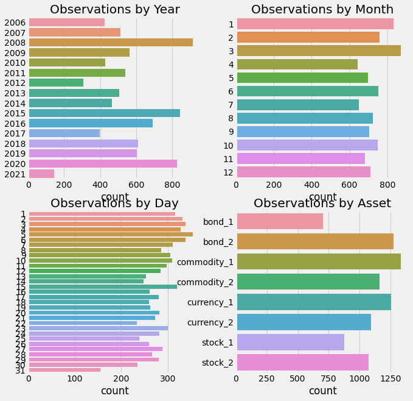

```python
fig, ax = plt.subplots(figsize=(10, 10), ncols = 2, nrows = 2)
sns.countplot(y=df2['Year'].values, ax = ax[0, 0])
ax[0, 0].set_title("Observations by Year");
sns.countplot(y=df2['Month'].values, ax = ax[0, 1])
ax[0, 1].set_title("Observations by Month");
sns.countplot(y=df2['Day'].values, ax = ax[1, 0])
ax[1, 0].set_title("Observations by Day");
sns.countplot(y=df2['Market'].values, ax = ax[1, 1])
ax[1, 1].set_title("Observations by Asset");
```

Distribution of Returns; Returns look leptokurtif / fat-tailed. Although Autocorrelation is likely computed incorrectly, there seems to be some levels of clustering in trading returns.

```
(-0.2, 0.2)
```

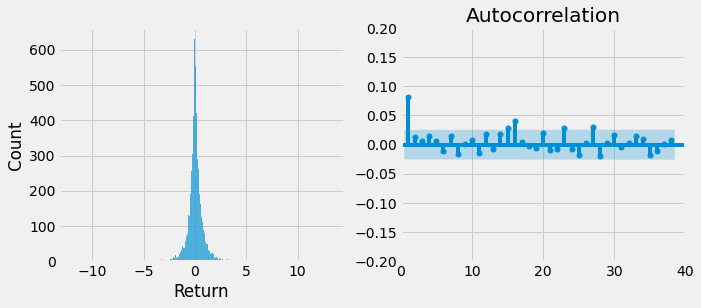

```python
fig, ax = plt.subplots(ncols = 2, figsize=(10, 4))
sns.histplot(df2['Return'], ax = ax[0])
rets = df.groupby(pd.to_datetime(df['Position_Open']))['Return'].mean()
plot_acf(rets, ax = ax[1]);
ax[1].set_xlim([0, 40]);
ax[1].set_ylim([-0.2, 0.2]);
```

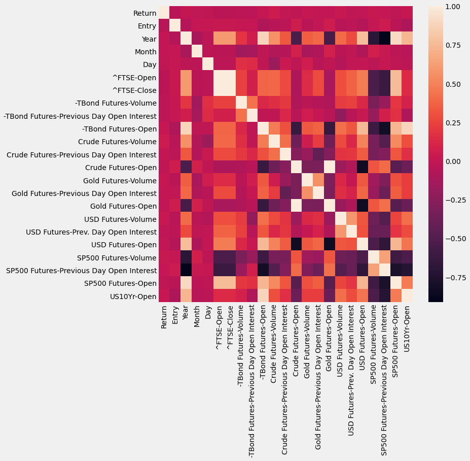

```python
fig, ax = plt.subplots(figsize=(10, 10))
sns.heatmap(df2.corr())
```

```python
df2.columns
```

[output not shown]

Features have some, but limited signal with trading return

```python
df2.corrwith(df2['Return']).abs().sort_values(ascending=False)
```

```
Return                                       1.000000
^VIX-Close                                   0.082373
^VIX-Open                                    0.080933
Crude Futures-Volume                         0.050153
Entry                                        0.039781
^FTSE-Close                                  0.037595
^FTSE-Open                                   0.037567
USDGBP=X-Rets                                0.034474
EURGBP=X-Rets                                0.033328
-TBond Futures-Volume                        0.028739
USD Futures-Volume                           0.027646
SP500 Futures-Volume                         0.026102
-TBond Futures-Previous Day Open Interest    0.025513
US10Yr-Open                                  0.020462
Gold Futures-Volume                          0.016130
-TBond Futures-Open                          0.015148
Day                                          0.014485
^FTSE-Rets                                   0.013847
^GSPC-Open                                   0.012689
^GSPC-Close                                  0.012655
USD Futures-Prev. Day Open Interest          0.012611
SP500 Futures-Previous Day Open Interest     0.011384
SP500 Futures-Open                           0.010007
Crude Futures-Open                           0.009365
Gold Futures-Open                            0.008974
USD Futures-Open                             0.007598
EURGBP=X-Open                                0.005811
Crude Futures-Previous Day Open Interest     0.004457
Month                                        0.004252
EURGBP=X-Close                               0.003736
^VIX-Rets                                    0.002473
USDGBP=X-Open                                0.001289
^GSPC-Rets                                   0.000603
USDGBP=X-Close                               0.000309
Year                                         0.000163
Gold Futures-Previous Day Open Interest      0.000027
dtype: float64
```

```python
np.unique(list(map(str,pd.to_datetime(df['Position_Open']).dt.time)))
```

```
array(['15:00:00', '15:30:00', '16:00:00', '16:30:00', '17:00:00',
       '17:30:00', '18:00:00', '18:30:00', '19:00:00', '19:30:00'],
      dtype='<U8')
```

For additional features, We could also potenitally include further lags of OI, volume and other features

# Modelling: LightGBM

We use Gradient Tree Boosting because of the lack of knowledge of the *time series structure* of the data. LightGBM is a popular variant of gradient boosted trees that allows for relatively fast training

We test multiple position-sizing strategies, which could be something that is further investigated:

- Long-short, predict a value between [-1, 1]
- Hard-classification Long-Short, predict -1, 0, 1
- Long-only, predict a value between [0, 1]
- Hard-classification Long only: predict or 0, 1

```python
sharpe = lambda x: np.mean(x / np.std(x))
# position sizing strategies
identity = lambda p: p
ls_pos = lambda p: 2 * p - 1 # scale prediction p so that it is between [-1, 1]
hard_l = lambda p: p > 0.5 # hard boundary, so the signal is either [0, 1]
hard_ls = lambda p: np.rint(2 * (p > 0.5) - 1) # hard boundary, the signal is either -1, 1
```

```python
drop_feats = ['Date','Year','Return']
X_train, X_val, X_test, y_train, y_val, y_test, train_ind, val_ind, test_ind = split(df2, drop_feats = drop_feats)

### LightGBM Model ###
train_data = lgb.Dataset(X_train, label = y_train > 0, categorical_feature = ['Market','Entry','Month','Day'])
val_data = lgb.Dataset(X_val, label = y_val > 0,categorical_feature = ['Market','Entry','Month','Day'])

SEED = random.randint(0, 999999)
print("SEED", SEED, "\n")

param = {"num_leaves": 64,
           "max_depth":8,
           "objective": "binary",
           "num_round": 500,
           "verbose": -1,
         "early_stopping_rounds":20,
           "seed": SEED}

evals_result = {}
bst = lgb.train(param, train_data, valid_sets=[val_data],evals_result=evals_result,verbose_eval=False)

train_preds = bst.predict(X_train)
val_preds = bst.predict(X_val)
test_preds = bst.predict(X_test)

#### Write Results ####
try:
    results = pd.read_csv(f"{path}/backtest_log.csv")
except:
    baseline = list(map(sharpe, [y_train, y_val, y_test])) + ['always long']
    perfect = list(map(lambda x: sharpe(abs(x)), [y_train, y_val, y_test])) + ['perfect sharpe']
    results = pd.DataFrame([baseline, perfect], columns=['train_sharpe','val_sharpe','test_sharpe','description'])

for description, f in zip(["LGB Classification (probability)", "LGB Classification (2x - 1 scaling)",
              "LGB Hard Classification Long-only", "LGB Hard Classification Long-Short"],
             [identity, ls_pos, hard_l, hard_ls]):

    temp = pd.DataFrame([[sharpe(f(train_preds) * y_train), sharpe(f(val_preds) * y_val),
                     sharpe(f(test_preds) * y_test), description, str(param)]])
    temp.columns = ['train_sharpe','val_sharpe','test_sharpe','description', 'hyperparameters']
    results = pd.concat([results, temp], axis = 0)

results = results.drop_duplicates(subset=['train_sharpe','test_sharpe','val_sharpe'])
results.reset_index(drop=True).to_csv(f"{path}/backtest_log.csv", index=False)
display(results)
```

```
(5497, 35) (5497,)
(1089, 35) (1089,)
(1214, 35) (1214,)

SEED 14481
```

|  | train_sharpe | val_sharpe | test_sharpe | description | hyperparameters |
| --- | --- | --- | --- | --- | --- |
| 0 | 0.087039 | -0.003976 | 0.066723 | always long | NaN |
| 1 | 0.695343 | 0.826045 | 0.809421 | perfect sharpe | NaN |
| 2 | 0.094210 | -0.003556 | 0.067892 | LGB Classification (probability) | {'num_leaves': 64, 'max_depth': 8, 'objective'... |
| 3 | 0.195920 | 0.003650 | 0.078369 | LGB Classification (2x - 1 scaling) | {'num_leaves': 64, 'max_depth': 8, 'objective'... |
| 4 | 0.125941 | 0.009718 | 0.079376 | LGB Hard Classification Long-only | {'num_leaves': 64, 'max_depth': 8, 'objective'... |
| 5 | 0.152040 | 0.022515 | 0.085299 | LGB Hard Classification Long-Short | {'num_leaves': 64, 'max_depth': 8, 'objective'... |
| 6 | 0.094210 | -0.003556 | 0.067892 | LGB Classification (probability) | {'num_leaves': 64, 'max_depth': 8, 'objective'... |
| 7 | 0.195920 | 0.003650 | 0.078369 | LGB Classification (2x - 1 scaling) | {'num_leaves': 64, 'max_depth': 8, 'objective'... |
| 8 | 0.094210 | -0.003556 | 0.067892 | LGB Classification (probability) | {'num_leaves': 64, 'max_depth': 8, 'objective'... |
| 9 | 0.195920 | 0.003650 | 0.078369 | LGB Classification (2x - 1 scaling) | {'num_leaves': 64, 'max_depth': 8, 'objective'... |
| 10 | 0.125941 | 0.009718 | 0.079376 | LGB Hard Classification Long-only | {'num_leaves': 64, 'max_depth': 8, 'objective'... |
| 11 | 0.152040 | 0.022515 | 0.085299 | LGB Hard Classification Long-Short | {'num_leaves': 64, 'max_depth': 8, 'objective'... |
| 12 | 0.101515 | -0.002767 | 0.068175 | LGB Classification (probability) | {'num_leaves': 64, 'max_depth': 8, 'objective'... |
| 13 | 0.257908 | 0.017378 | 0.034970 | LGB Classification (2x - 1 scaling) | {'num_leaves': 64, 'max_depth': 8, 'objective'... |
| 14 | 0.184922 | 0.014136 | 0.072440 | LGB Hard Classification Long-only | {'num_leaves': 64, 'max_depth': 8, 'objective'... |
| 15 | 0.243896 | 0.025946 | 0.036663 | LGB Hard Classification Long-Short | {'num_leaves': 64, 'max_depth': 8, 'objective'... |
| 16 | 0.090049 | -0.003145 | 0.066260 | LGB Classification (probability) | {'num_leaves': 16, 'max_depth': 5, 'objective'... |
| 17 | 0.139830 | 0.017840 | 0.031175 | LGB Classification (2x - 1 scaling) | {'num_leaves': 16, 'max_depth': 5, 'objective'... |
| 18 | 0.103940 | -0.000008 | 0.051410 | LGB Hard Classification Long-only | {'num_leaves': 16, 'max_depth': 5, 'objective'... |
| 19 | 0.116588 | 0.003964 | 0.019999 | LGB Hard Classification Long-Short | {'num_leaves': 16, 'max_depth': 5, 'objective'... |
| 20 | 0.087757 | -0.003981 | 0.066486 | LGB Classification (probability) | {'num_leaves': 16, 'max_depth': 2, 'objective'... |
| 21 | 0.102373 | -0.003815 | 0.055379 | LGB Classification (2x - 1 scaling) | {'num_leaves': 16, 'max_depth': 2, 'objective'... |
| 22 | 0.087039 | -0.003976 | 0.066723 | LGB Hard Classification Long-only | {'num_leaves': 16, 'max_depth': 2, 'objective'... |
| 0 | 0.184922 | 0.014136 | 0.072440 | LGB Hard Classification Long-only | {'num_leaves': 64, 'max_depth': 8, 'objective'... |
| 0 | 0.243896 | 0.025946 | 0.036663 | LGB Hard Classification Long-Short | {'num_leaves': 64, 'max_depth': 8, 'objective'... |

## Evaluation: Predictions

In addition to evaluating the performance of the model in terms of Sharpe, we can evaluate the performance of the model in terms of its *machine learning* performance. FOr many of our runs, we find that the validation error consistently increases.

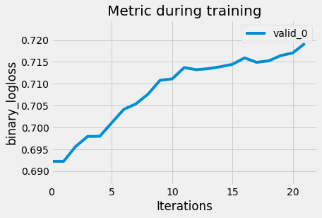

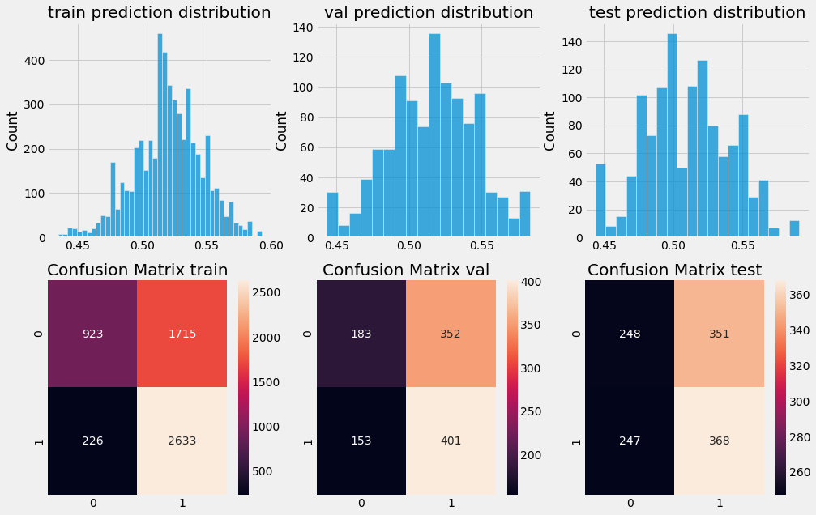

```python
lgb.plot_metric(evals_result)
fig, ax = plt.subplots(ncols = 3, figsize=(15, 10), nrows = 2)
names = ["train","val","test"]
for i, x in enumerate(zip([train_preds, val_preds, test_preds], [y_train, y_val, y_test])):
    sns.histplot(x[0], ax = ax[0, i])
    ax[0, i].set_title(f"{names[i]} prediction distribution")
    sns.heatmap(confusion_matrix(x[1] > 0, x[0] > 0.5), ax=ax[1, i],annot=True, fmt='g')
    ax[1, i].set_title(f"Confusion Matrix {names[i]}")
```

## Evaluation: Interpretability

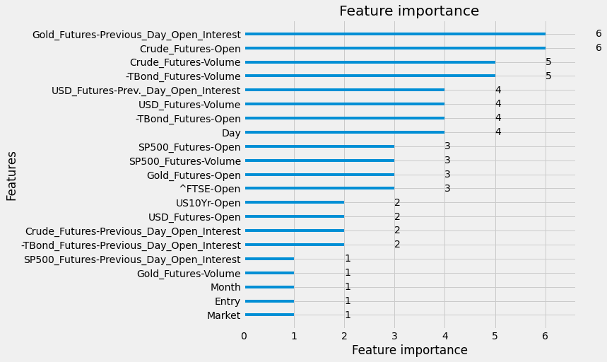

```python
#### Diagnosis ####
fig, ax = plt.subplots(figsize=(7.5, 7.5))
lgb.plot_importance(bst, ax)
```

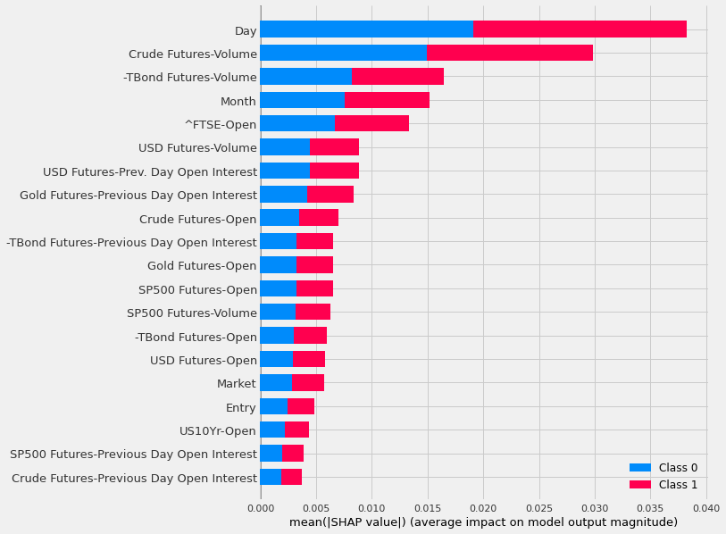

```python
explainer = shap.TreeExplainer(bst)
shap_values = explainer.shap_values(X_train)
shap.summary_plot(shap_values, feature_names = X_train.columns)
```

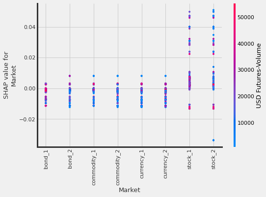

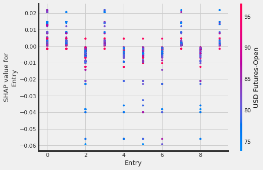

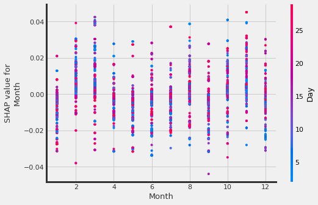

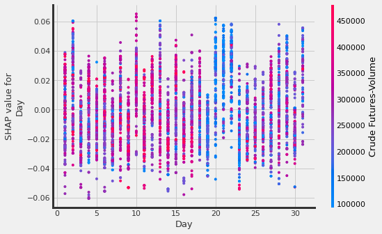

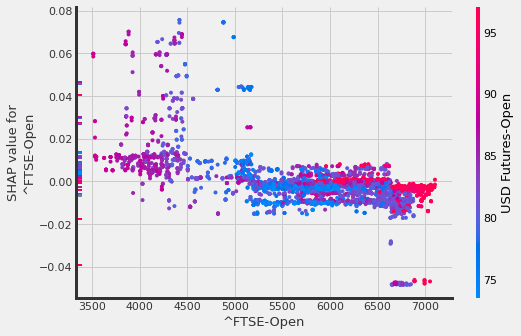

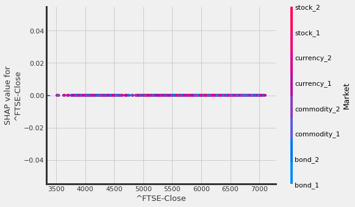

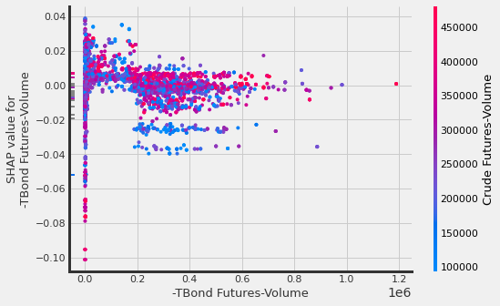

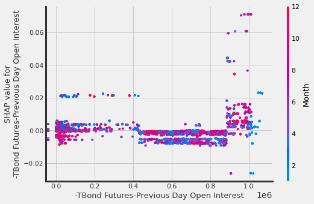

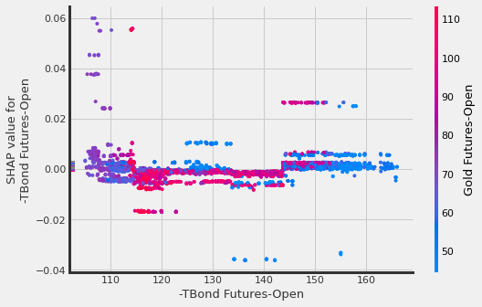

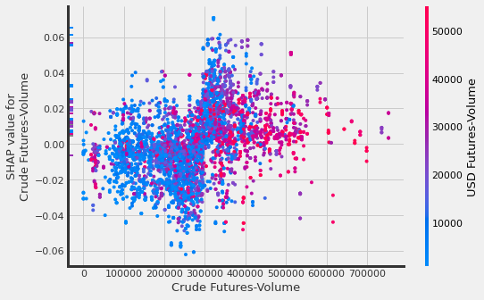

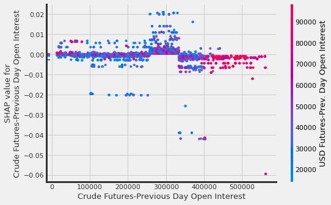

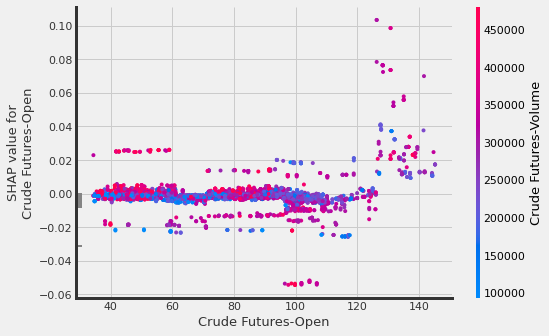

[10 more figures not shown]

```python
for i,x in enumerate(X_train.columns):
    shap.dependence_plot(i, shap_values[1], X_train)
```